# Tarea 1. Extracción de datos en tres enfoques

Datos no Estructurados

Autor/a

María Yu García Muñoz — 4º BIA

Fecha de publicación

20 de octubre de 2025

## Introducción

En esta práctica hemos analizado la **evolución del turismo internacional** entre los años 1995 y 2020, tomando como referencia tres enfoques complementarios: el **volumen de turistas**, el **gasto turístico internacional** y la **capacidad de alojamiento turístico de corta estancia**. Nuestro objetivo ha sido comprender no solo cómo ha cambiado la demanda turística a lo largo del tiempo, sino también cómo esta se refleja en la inversión y en la infraestructura disponible, permitiéndonos identificar patrones globales y comparativos entre los países líderes del sector.

## Bloque 1: Llegadas internacionales de turistas

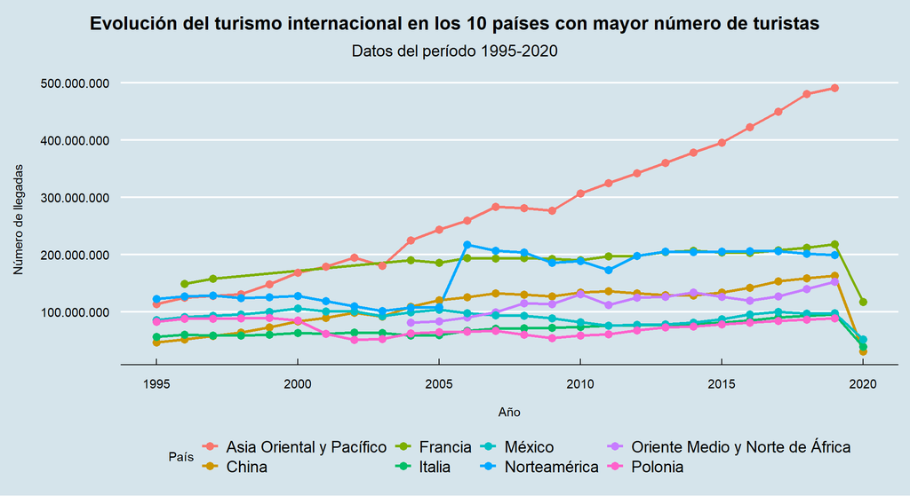

```r
# Leer XML desde archivo local

xml_file <- "C:\\Users\\ymari\\Downloads\\API_ST.INT.ARVL_DS2_en_xml_v2_21512\\API_ST.INT.ARVL_DS2_en_xml_v2_21512.xml"
xml <- read_xml(xml_file)

# Extraer registros

records <- xml_find_all(xml, "//record")

# Función para parsear cada registro a tibble

parse_record <- function(record) {
fields <- xml_find_all(record, ".//field")
tibble(
country = xml_text(fields[xml_attr(fields, "name") == "Country or Area"]),
country_code = xml_attr(fields[xml_attr(fields, "name") == "Country or Area"], "key"),
item = xml_text(fields[xml_attr(fields, "name") == "Item"]),
item_code = xml_attr(fields[xml_attr(fields, "name") == "Item"], "key"),
year = xml_text(fields[xml_attr(fields, "name") == "Year"]),
value = xml_text(fields[xml_attr(fields, "name") == "Value"])
)
}

df <- map_df(records, parse_record)

# Convertir a numéricos y limpiar

df <- df %>%
mutate(
year = as.integer(year),
value = as.numeric(value)
) %>%
filter(!is.na(value))

# Filtrar países válidos

df_paises <- df %>%
  filter(!grepl(
    "\\(|area|region|income|countries|Caribbean|Baltics|Euro|demographic|IBRD|IDA|World|Union|OECD|Fragile|conflict|small states|excl|total|group",
    country, ignore.case = TRUE))


# Selección top 10 países con mayor número de turistas

top10_countries <- df_paises %>%
group_by(country) %>%
summarise(total_tourists = sum(value, na.rm = TRUE)) %>%
arrange(desc(total_tourists)) %>%
slice(1:10) %>%
pull(country)

nombres_esp <- tibble(
country = c("China", "France", "Mexico", "East Asia & Pacific", "Italy",
"Middle East, North Africa, Afghanistan & Pakistan",
"North America", "Poland"),
country_es = c("China", "Francia", "México", "Asia Oriental y Pacífico",
"Italia", "Oriente Medio y Norte de África",
"Norteamérica", "Polonia")
)

df_plot <- df %>%
left_join(nombres_esp, by = "country") %>%
mutate(country_final = if_else(!is.na(country_es), country_es, country))

ggplot(df_plot %>% filter(country_final %in% nombres_esp$country_es),
aes(x = year, y = value, color = country_final, group = country_final)) +
geom_line(size = 1.2) +
geom_point(size = 3) +
scale_x_continuous(limits = c(1995, max(df$year, na.rm = TRUE))) +
scale_y_continuous(labels = comma_format(big.mark = ".", decimal.mark = ",")) +
labs(
title = "Evolución del turismo internacional en los 10 países con mayor número de turistas",
subtitle = "Datos del período 1995-2020",
x = "Año",
y = "Número de llegadas",
color = "País"
) +
theme_economist() +
theme(
  plot.title.position = "plot",
  plot.title = element_text(face = "bold", size = 16, hjust = 0.5, margin = margin(b = 10)),
  plot.subtitle = element_text(size = 14, hjust = 0.5, margin = margin(b = 15)),
  axis.title.x = element_text(margin = margin(t = 15)),
  axis.title.y = element_text(margin = margin(r = 15)),
  legend.position = "bottom"
)
```

Figura 1

Por otra parte, no podemos obviar que en 2020 el turismo internacional sufrió una caída drástica debido a la pandemia de COVID-19. Las restricciones de movilidad, los cierres de fronteras y las medidas de distanciamiento social provocaron que el flujo de turistas internacionales disminuyera hasta un 70% a nivel global respecto a 2019. Esta caída representa un impacto sin precedentes que afectó tanto a la demanda como a la oferta turística, generando una paralización casi total de las actividades de ocio y viajes durante gran parte del año. Además, la incertidumbre persistente y las sucesivas oleadas de contagios frenaron significativamente la posible recuperación del sector.

## Bloque 2: Gasto turístico internacional

En segundo lugar, hemos analizado el **gasto turístico internacional**, extraído a través de la API del World Bank. Este bloque nos permite estudiar no solo cuántos turistas se desplazan, sino **cuánto dinero gastan**, lo que aporta una dimensión económica al análisis de la demanda turística.

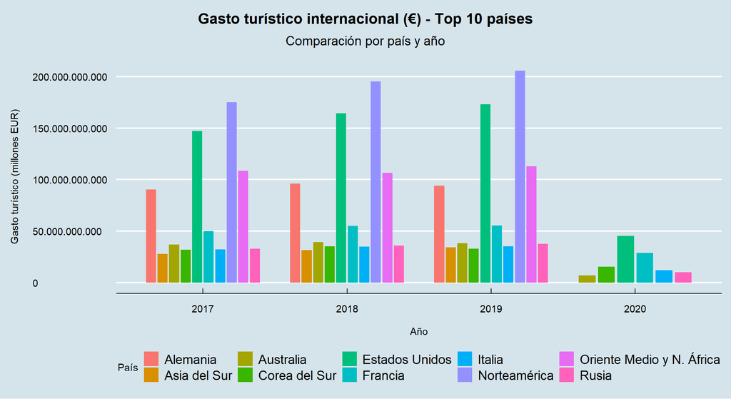

```r
# URL de la API
url_api <- "http://api.worldbank.org/v2/country/all/indicator/ST.INT.XPND.CD?format=json&date=1995:2020&per_page=20000"

# Petición GET
res <- httr::GET(url_api)
stop_for_status(res)

# Convertir a texto y luego JSON
txt <- content(res, as = "text", encoding = "UTF-8")
j <- fromJSON(txt, flatten = TRUE)

# Extraer el dataframe del JSON
df_gastos <- as_tibble(j[[2]]) %>%
  select(country = country.value, country_code = country.id, year = date, value) %>%
  mutate(year = as.integer(year),
         value = as.numeric(value)) %>%
  filter(!is.na(value))

# Filtrar países/regiones que no nos interesan
excluded_patterns <- "\\$$|area|region|income|countries|Caribbean|Baltics|Euro|demographic|IBRD|IDA|World|Union|OECD|Fragile|conflict|small states|excl|total|group"
df_gastos <- df_gastos %>%
  filter(!grepl(excluded_patterns, country, ignore.case = TRUE))

# Conversión a euros
tipo_cambio <- 0.93
df_gastos <- df_gastos %>%
  mutate(value_eur = value * tipo_cambio)

# Últimos 4 años
ultimo_anio <- max(df_gastos$year)
ultimos_anos <- (ultimo_anio-3):ultimo_anio

# Top 10 países por gasto
top10_gastos <- df_gastos %>%
  filter(year %in% ultimos_anos) %>%
  group_by(country) %>%
  summarise(total_gasto = sum(value_eur, na.rm = TRUE)) %>%
  arrange(desc(total_gasto)) %>%
  slice_head(n = 10) %>%
  pull(country)

df_top_gastos <- df_gastos %>%
  filter(country %in% top10_gastos, year %in% ultimos_anos)

nombres_esp_gasto <- tribble(
  ~country, ~pais,
  "Australia", "Australia",
  "France", "Francia",
  "Germany", "Alemania",
  "Italy", "Italia",
  "Korea, Rep.", "Corea del Sur",
  "Middle East, North Africa, Afghanistan & Pakistan", "Oriente Medio y N. África",
  "North America", "Norteamérica",
  "Russian Federation", "Rusia",
  "South Asia", "Asia del Sur",
  "United States", "Estados Unidos"
)

df_top_gastos_plot <- df_top_gastos %>%
  left_join(nombres_esp_gasto, by = "country") %>%
  mutate(pais = if_else(!is.na(pais), pais, country))



ggplot(df_top_gastos_plot, aes(x = factor(year), y = value_eur, fill = pais)) +
  geom_col(position = position_dodge(width = 0.8), width = 0.7) +
  scale_y_continuous(labels = comma_format(big.mark = ".", decimal.mark = ",")) +
  labs(
    title = "Gasto turístico internacional (€) - Top 10 países",
    subtitle = "Comparación por país y año",
    x = "Año", y = "Gasto turístico (millones EUR)", fill = "País"
  ) +
  theme_economist() +
theme(
  plot.title.position = "plot",
  plot.title = element_text(face = "bold", size = 16, hjust = 0.5, margin = margin(b = 10)),
  plot.subtitle = element_text(size = 14, hjust = 0.5, margin = margin(b = 15)),
  axis.title.x = element_text(margin = margin(t = 15)),
  axis.title.y = element_text(margin = margin(r = 15)),
  legend.position = "bottom"
)
```

Con este nuevo gráfico podemos confirmar la importancia de analizar no solo la cantidad de visitantes, sino el impacto económico que implican sus desplazamientos.

Si nos fijamos en los años previos a la pandemia, entre 2017 y 2019, se mantiene una tendencia bastante estable en el gasto turístico de los países que lideran el ranking, con Norteamérica y Estados Unidos en posiciones destacadas. Sin embargo, en 2020 todas las columnas bajan de golpe, lo que refleja perfectamente el efecto que tuvo la COVID-19 en el sector: no solo viajaron menos personas, sino que el dinero que se movió en el sector se redujo drásticamente a nivel mundial. Lo cual demuestra lo vulnerable que es la industria turística ante situaciones tan impredecibles como una crisis sanitaria.

## Bloque 3: Capacidad de alojamiento turístico

Finalmente, hemos analizado la capacidad de alojamiento de corta estancia a partir de los datos obtenidos de la web NationMaster, enfocándonos en los 10 países líderes en este indicador. Para realizar la extracción, hemos epleado Google Sheets, utilizando la funcion IMPORTHTML para importar directamente la información estructurada desde la página web para después exportar los datos en formato Excel (.xlsx).

Este indicador nos permitirá estudiar la respuesta de la oferta turística frente a la demanda.

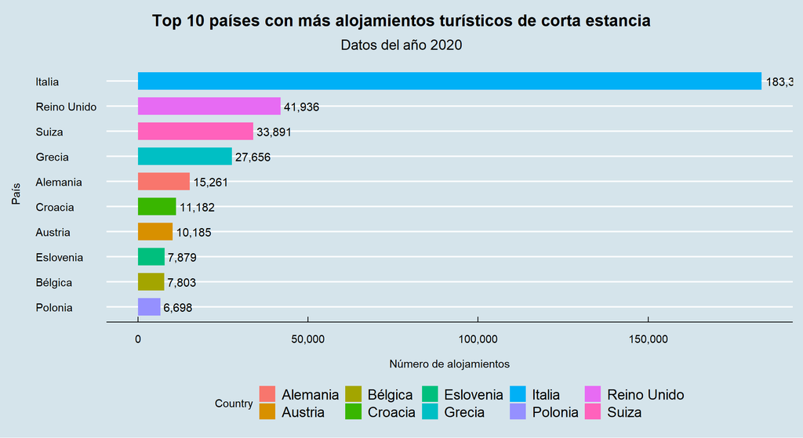

```r
# Ruta del archivo Excel descargado con los datos de alojamiento
ruta_xlsx <- "D:\\4 curso\\DNE\\DNE\\bloque_3.xlsx"

# Leer el archivo Excel y asignar tipos de columna (todo texto para limpiar más fácil)
df_gsheet <- read_excel(ruta_xlsx, col_types = c("text", "text", "text"))


colnames(df_gsheet) <- c("Country", "Units (Establishments)", "Year")

# Limpiar y transformar los datos principales
df_gsheet_limpio <- df_gsheet %>%
  # Quitar posibles prefijos numéricos y espacios extra en la columna país
  mutate(
    Country = str_trim(str_remove(Country, "^#\\d+\\s*")),
    # Convertir unidades de alojamiento a formato numérico, eliminando los puntos de miles
    `Units (Establishments)` = as.numeric(gsub("\\.", "", `Units (Establishments)`)),
    # Convertir año a numérico
    Year = as.numeric(Year)
  ) %>%
  select(Country, `Units (Establishments)`, Year)

# Traducir los nombres de país al español para facilitar la interpretación del gráfico y la tabla
df_gsheet_limpio <- df_gsheet_limpio %>%
  mutate(Country = recode(Country,
    "Italy" = "Italia",
    "Belgium" = "Bélgica",
    "Poland" = "Polonia",
    "Romania" = "Rumanía",
    "Portugal" = "Portugal",
    "France" = "Francia",
    "Greece" = "Grecia",
    "Spain" = "España",
    "Turkey" = "Turquía",
    "Germany" = "Alemania",
    "Croatia" = "Croacia",
    "Switzerland" = "Suiza",
    "Slovenia" = "Eslovenia",
    "United Kingdom" = "Reino Unido",
    .default = Country
  ))

# Seleccionar los 10 países con más alojamientos de corta estancia para visualización
df_gsheet_top10 <- df_gsheet_limpio %>%
  arrange(desc(`Units (Establishments)`)) %>%
  slice_head(n = 10)

ggplot(df_gsheet_top10, aes(x = reorder(Country, `Units (Establishments)`), y = `Units (Establishments)`, fill = Country)) +
  geom_col(width = 0.7) +
  coord_flip() +
  geom_text(aes(label = scales::comma(round(`Units (Establishments)`, 0))), hjust = -0.1, size = 4) +
  scale_y_continuous(labels = scales::comma) +
  labs(
    title = "Top 10 países con más alojamientos turísticos de corta estancia",
    subtitle = paste("Datos del año", max(df_gsheet_top10$Year)),
    x = "País",
    y = "Número de alojamientos"
  ) +
  theme_economist() +
theme(
  plot.title.position = "plot",
  plot.title = element_text(face = "bold", size = 16, hjust = 0.5, margin = margin(b = 10)),
  plot.subtitle = element_text(size = 14, hjust = 0.5, margin = margin(b = 15)),
  axis.title.x = element_text(margin = margin(t = 15)),
  axis.title.y = element_text(margin = margin(r = 15)),
  legend.position = "bottom"
)
```

Al observar los datos más recientes y la representación gráfica, vemos que Italia, Reino Unido y Suiza se posicionan claramente como los países con mayor número de alojamientos turísticos de corta estancia.

Por ejemplo, en el caso de Italia, no solo vemos que lidera en el número de alojamientos turísticos disponibles, sino que además lleva años siendo uno de los destinos favoritos y más rentables de todo el mundo. De hecho, el país ha sabido ajustar su capacidad hotelera y de otros tipos de alojamiento para adaptarse a una demanda que no deja de crecer, lo que a su vez le ayuda a mantenerse competitivo frente a otros países. Cuando analizamos juntos el número total de visitantes, el gasto medio por turista y toda la infraestructura que pone a su disposición, entendemos mucho mejor por qué Italia, y otros países similares, se mantienen en lo más alto del turismo internacional.

```r
DT::datatable(df_gsheet_limpio,
  options = list(pageLength = 15, autoWidth = TRUE),
  caption = 'Tabla completa de alojamientos turísticos'
)
```

|  | Country | Units (Establishments) | Year |
| --- | --- | --- | --- |
| 1 | Italia | 183316 | 2019 |
| 2 | Croacia | 11182 | 2019 |
| 3 | Reino Unido | 41936 | 2019 |
| 4 | Suiza | 33891 | 2018 |
| 5 | España | 3192 | 2019 |
| 6 | Grecia | 27656 | 2019 |
| 7 | Alemania | 15261 | 2019 |
| 8 | Austria | 10185 | 2020 |
| 9 | Eslovenia | 7879 | 2019 |
| 10 | Bélgica | 7803 | 2019 |

[output cut: 24 more lines]

## Conclusión

Además, se evidencia una diversificación del turismo global, donde algunos países priorizan volumen y otros valor económico por visitante. Europa occidental, en particular, combina un alto volumen de turistas, un gasto significativo y una amplia oferta de alojamiento, consolidándose como la región líder en turismo internacional. También queda patente que factores externos, como crisis económicas, políticas de turismo o eventos globales, pueden afectar de manera simultánea la llegada de turistas, el gasto y la inversión en infraestructura.

Esta combinación entre una oferta amplia de alojamientos, un flujo constante de turistas y un gasto turístico elevado nos muestra que cuando un país invierte en tener suficiente infraestructura y variedad para alojar visitantes, no solo logra atraerlos, sino también que regresen y recomienden ese destino.

En definitiva, el análisis integrado de llegadas, gasto y oferta nos proporciona una visión completa del fenómeno turístico, permitiéndonos identificar patrones estratégicos y económicos relevantes. La combinación de infraestructura adecuada, flujo constante de turistas y gasto elevado es la clave para que un país se mantenga competitivo y siga creciendo como destino turístico en el tiempo.

## Webgrafía

1. Moncanig. (2025). *Tema 2: Análisis del turismo internacional*. Recuperado de https://moncanig.quarto.pub/dne2526/Tema2.html
2. Organización Mundial del Turismo (OMT). (2019). *Informe sobre el turismo mundial 2019*. Recuperado de https://www.e-unwto.org/doi/pdf/10.18111/9789284413515
3. Travel Weekly. (2025, 19 de octubre). *The pot gets bigger: Vegas draws record 38.9M people*. Recuperado de https://www.travelweekly.com/North-America-Travel/The-pot-gets-bigger-Vegas-draws-record-38-9M-people
4. The Moodie Davitt Report. (2006, 29 de junio). *International tourism up 4.5% in January to April 2006, says World Tourism Organization*. Recuperado de https://moodiedavittreport.com/international-tourism-up-4-5-in-january-to-april-2006-says-world-tourism-organization-290606/
5. Organización Mundial del Turismo (OMT). (2025). *Estadísticas de turismo y alojamiento*. Recuperado de https://www.untourism.int/tourism-statistics/tourism-data-tourism-accommodation
6. National IT Industry Promotion Agency (NIPA). (2025). *Estadísticas de alojamiento turístico en Corea del Sur*. Recuperado de https://nia.or.kr/site/nia_kor/ex/bbs/View.do?cbIdx=99835&bcIdx=28652&parentSeq=28652
7. Banco Mundial. (2025). *Gasto en turismo internacional (ST.INT.XPND.CD)*. Recuperado de https://data.worldbank.org/indicator/ST.INT.XPND.CD?end=2020&locations=Z4&name_desc=false&start=1995&view=chart&year=1995
8. NationMaster. (2025). *Ranking de número de establecimientos de alojamiento de corta estancia*. Recuperado de https://www.nationmaster.com/nmx/ranking/number-of-short-stay-accommodations-establishments
9. Naciones Unidas. (2025). *Estadísticas de turismo internacional*. Recuperado de https://data.un.org/DocumentData.aspx?id=482